# 임베딩 모델 비교 테스트 결과

**Cross-Domain 법안 감지를 위한 임베딩 모델 성능 평가**

- Project: Popcorn
- Date: 2026-01-15
- Version: v1 (법안명만 사용)

## 1. 개요

### 1.1 테스트 목적

타 상임위 소관 법안 중 **산업통상자원부 R&R과 연관된 법안**을 선제 감지하기 위한 최적의 임베딩 모델을 선정합니다.

### 1.2 테스트 대상 모델

| 모델 | 제공사 | 특징 |
| --- | --- | --- |
| Solar Embedding | Upstage | 한국어 특화, API 기반 |
| text-embedding-3-small | OpenAI | 다국어 지원, 저비용 |
| Multilingual-E5-Large | Intfloat | 오픈소스, 로컬 실행 |

### 1.3 평가 데이터

- **R&R 데이터**: 산업통상자원부 R&R (증강 버전, 822자)
- **테스트 법안**: 22대 국회 법안 100건 (10개 상임위 × 10건)
- **Golden Set**: Cross-Domain 감지 테스트용 5건

## 2. Golden Set 구성

```python
import json
import pandas as pd
from pathlib import Path

# 데이터 로드 (research/reports/ 기준)
data_dir = Path("../../data")
golden_data = json.load(open(data_dir / "golden_set.json", encoding="utf-8"))

golden_df = pd.DataFrame(golden_data["bills"])
golden_df = golden_df[["golden_id", "difficulty", "bill_name", "committee", "propose_dt"]]
golden_df.columns = ["ID", "난이도", "법안명", "소관위", "발의일"]
golden_df
```

|  | ID | 난이도 | 법안명 | 소관위 | 발의일 |
| --- | --- | --- | --- | --- | --- |
| 0 | golden_1 | Easy | 기후위기 대응을 위한 탄소중립ㆍ녹색성장 기본법 일부개정법률안 | 기후위기 특별위원회 | 2026-01-09 |
| 1 | golden_2 | Easy | 중대재해 처벌 등에 관한 법률 일부개정법률안 | 법제사법위원회 | 2025-09-05 |
| 2 | golden_3 | Medium | 개인정보 보호법 일부개정법률안 | None | 2026-01-14 |
| 3 | golden_4 | Hard | 약사법 일부개정법률안 | 보건복지위원회 | 2026-01-06 |
| 4 | golden_5 | Hard | 국유재산특례제한법 일부개정법률안 | 재정경제기획위원회 | 2026-01-13 |

### 2.1 Golden Set 선정 기준

| 난이도 | 선정 기준 | 예시 |
| --- | --- | --- |
| **Easy** | 산업부 키워드 직접 포함 | 탄소중립, 중대재해 |
| **Medium** | 간접 연관 (데이터, AI) | 개인정보보호법 |
| **Hard** | Cross-Domain 핵심 타겟 | 약사법(공장 설비), 국유재산특례제한법(세제) |

## 3. 테스트 결과

```python
# 결과 로드
results_path = Path("../results/embedding_comparison.json")
results = json.load(open(results_path, encoding="utf-8"))

# 종합 비교표 생성
summary_data = []
for model_key in ["solar", "openai", "multilingual_e5"]:
    if model_key in results and "evaluation" in results[model_key]:
        eval_data = results[model_key]["evaluation"]
        summary_data.append({
            "모델": results[model_key]["model"],
            "Recall@10": f"{eval_data['recall_at_10']:.1%}",
            "Recall@20": f"{eval_data['recall_at_20']:.1%}",
            "Recall@50": f"{eval_data['recall_at_50']:.1%}",
            "Hard 평균순위": f"{eval_data['avg_hard_rank']:.1f}",
            "전체 평균순위": f"{eval_data['mean_rank']:.1f}"
        })

summary_df = pd.DataFrame(summary_data)
summary_df
```

|  | 모델 | Recall@10 | Recall@20 | Recall@50 | Hard 평균순위 | 전체 평균순위 |
| --- | --- | --- | --- | --- | --- | --- |
| 0 | Solar Embedding (Upstage) | 0.0% | 0.0% | 40.0% | 52.0 | 56.8 |
| 1 | text-embedding-3-small (OpenAI) | 0.0% | 0.0% | 40.0% | 45.0 | 64.0 |
| 2 | Multilingual-E5-Large (fastembed) | 0.0% | 20.0% | 20.0% | 62.5 | 50.2 |

### 3.1 Golden Set 상세 순위

```python
# Golden Set 순위 비교
golden_ranks_data = []

for model_key in ["solar", "openai", "multilingual_e5"]:
    if model_key in results and "evaluation" in results[model_key]:
        model_name = results[model_key]["model"].split(" (")[0]
        for g in results[model_key]["evaluation"]["golden_ranks"]:
            golden_ranks_data.append({
                "모델": model_name,
                "법안": g["bill_name"][:20] + "...",
                "난이도": g["difficulty"],
                "순위": g["rank"],
                "유사도": round(g["similarity"], 3)
            })

ranks_df = pd.DataFrame(golden_ranks_data)
ranks_pivot = ranks_df.pivot_table(
    index=["법안", "난이도"],
    columns="모델",
    values="순위",
    aggfunc="first"
).reset_index()
ranks_pivot
```

| 모델 | 법안 | 난이도 | Multilingual-E5-Large | Solar Embedding | text-embedding-3-small |
| --- | --- | --- | --- | --- | --- |
| 0 | 개인정보 보호법 일부개정법률안... | Medium | 58 | 88 | 95 |
| 1 | 국유재산특례제한법 일부개정법률안... | Hard | 74 | 49 | 32 |
| 2 | 기후위기 대응을 위한 탄소중립ㆍ녹색성... | Easy | 13 | 34 | 99 |
| 3 | 약사법 일부개정법률안... | Hard | 51 | 55 | 58 |
| 4 | 중대재해 처벌 등에 관한 법률 일부개... | Easy | 55 | 58 | 36 |

### 3.2 시각화

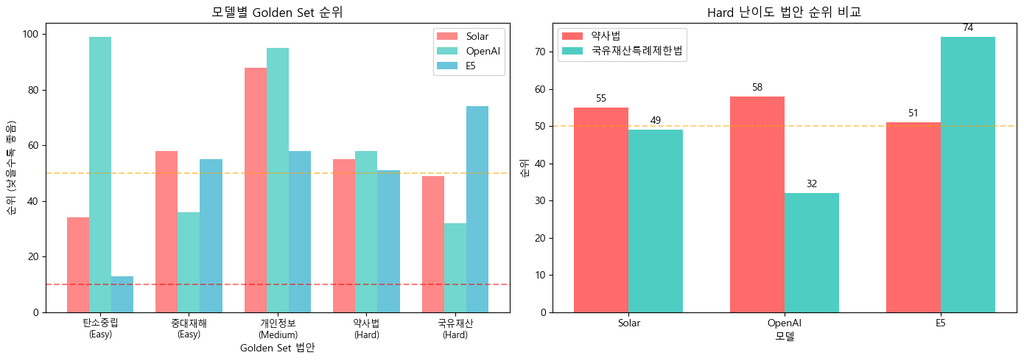

```python
import matplotlib.pyplot as plt

# 한글 폰트 설정
plt.rcParams['font.family'] = 'Malgun Gothic'
plt.rcParams['axes.unicode_minus'] = False

fig, axes = plt.subplots(1, 2, figsize=(14, 5))

# 1. 순위 비교 바 차트
models = ["Solar", "OpenAI", "E5"]
colors = ["#FF6B6B", "#4ECDC4", "#45B7D1"]

for model_key, model_name, color in zip(
    ["solar", "openai", "multilingual_e5"],
    models,
    colors
):
    if model_key in results and "evaluation" in results[model_key]:
        ranks = [g["rank"] for g in results[model_key]["evaluation"]["golden_ranks"]]
        x_pos = [0, 1, 2, 3, 4]
        offset = (models.index(model_name) - 1) * 0.25
        axes[0].bar([x + offset for x in x_pos], ranks, 0.25, label=model_name, color=color, alpha=0.8)

axes[0].set_xlabel("Golden Set 법안")
axes[0].set_ylabel("순위 (낮을수록 좋음)")
axes[0].set_title("모델별 Golden Set 순위")
axes[0].set_xticks(range(5))
axes[0].set_xticklabels(["탄소중립\n(Easy)", "중대재해\n(Easy)", "개인정보\n(Medium)", "약사법\n(Hard)", "국유재산\n(Hard)"], fontsize=9)
axes[0].legend()
axes[0].axhline(y=10, color='red', linestyle='--', alpha=0.5)
axes[0].axhline(y=50, color='orange', linestyle='--', alpha=0.5)

# 2. Hard 난이도 순위 비교
hard_ranks = {}
for model_key, model_name in zip(["solar", "openai", "multilingual_e5"], models):
    if model_key in results and "evaluation" in results[model_key]:
        hard = [g["rank"] for g in results[model_key]["evaluation"]["golden_ranks"] if g["difficulty"] == "Hard"]
        hard_ranks[model_name] = hard

ax2 = axes[1]
x = range(len(models))
width = 0.35
yaksa = [hard_ranks[m][0] for m in models]
guyu = [hard_ranks[m][1] for m in models]

bars1 = ax2.bar([i - width/2 for i in x], yaksa, width, label='약사법', color='#FF6B6B')
bars2 = ax2.bar([i + width/2 for i in x], guyu, width, label='국유재산특례제한법', color='#4ECDC4')

ax2.set_xlabel("모델")
ax2.set_ylabel("순위")
ax2.set_title("Hard 난이도 법안 순위 비교")
ax2.set_xticks(x)
ax2.set_xticklabels(models)
ax2.legend()
ax2.axhline(y=50, color='orange', linestyle='--', alpha=0.5)

for bar in bars1:
    ax2.text(bar.get_x() + bar.get_width()/2, bar.get_height() + 1, f'{int(bar.get_height())}', ha='center', va='bottom', fontsize=10)
for bar in bars2:
    ax2.text(bar.get_x() + bar.get_width()/2, bar.get_height() + 1, f'{int(bar.get_height())}', ha='center', va='bottom', fontsize=10)

plt.tight_layout()
plt.show()
```

## 4. 분석

### 4.1 주요 발견

1. **법안명만으로는 Cross-Domain 감지가 매우 어려움**
   - 3개 모델 모두 Recall@10 = 0%
   - Golden Set이 Top 10에 단 1건도 진입하지 못함
2. **Hard 난이도 감지력**
   - **OpenAI 우위**: 국유재산특례제한법 #32 (가장 좋음)
   - Solar: 국유재산특례제한법 #49
   - E5: 약사법 #51
3. **유사도 분포 특성**

```python
# 유사도 분포 분석
sim_data = []
for model_key, model_name in zip(["solar", "openai", "multilingual_e5"], ["Solar", "OpenAI", "E5"]):
    if model_key in results and "evaluation" in results[model_key]:
        sims = [g["similarity"] for g in results[model_key]["evaluation"]["golden_ranks"]]
        sim_data.append({
            "모델": model_name,
            "최소 유사도": f"{min(sims):.3f}",
            "최대 유사도": f"{max(sims):.3f}",
            "범위": f"{max(sims) - min(sims):.3f}"
        })

pd.DataFrame(sim_data)
```

|  | 모델 | 최소 유사도 | 최대 유사도 | 범위 |
| --- | --- | --- | --- | --- |
| 0 | Solar | 0.358 | 0.404 | 0.046 |
| 1 | OpenAI | 0.291 | 0.401 | 0.110 |
| 2 | E5 | 0.781 | 0.805 | 0.024 |

### 4.2 Top 10 소관위 분포

```python
# Top 10 소관위 분포
for model_key, model_name in zip(["solar", "openai", "multilingual_e5"], ["Solar", "OpenAI", "E5"]):
    if model_key in results and "top_10" in results[model_key]:
        committees = [b["committee"][:15] for b in results[model_key]["top_10"]]
        print(f"\n[{model_name}] Top 10 소관위 분포:")
        for c, cnt in pd.Series(committees).value_counts().items():
            print(f"  - {c}: {cnt}건")
```

```
[Solar] Top 10 소관위 분포:
  - 산업통상자원중소벤처기업위원회: 7건
  - 농림축산식품해양수산위원회: 2건
  - 교육위원회: 1건

[OpenAI] Top 10 소관위 분포:
  - 산업통상자원중소벤처기업위원회: 4건
  - 농림축산식품해양수산위원회: 4건
  - 교육위원회: 1건
  - 환경노동위원회: 1건

[E5] Top 10 소관위 분포:
  - 산업통상자원중소벤처기업위원회: 7건
  - 농림축산식품해양수산위원회: 1건
  - 기획재정위원회: 1건
  - 교육위원회: 1건
```

## 5. 한계점 및 개선 방향

### 5.1 현재 테스트의 한계

| 한계점 | 설명 |
| --- | --- |
| **법안명만 사용** | 제안이유, 주요내용 등 본문 미포함 |
| **의미적 정보 부족** | 짧은 법안명으로는 Cross-Domain 연관성 파악 어려움 |
| **Golden Set 규모** | 5건으로 통계적 유의성 제한적 |

### 5.2 개선 방향

1. **법안 본문 수집** - 열린국회정보 API에서 제안이유/주요내용 수집
2. **본문 포함 재테스트** - 의미적 유사도 정확도 향상 기대
3. **Reranker 추가** - 초기 검색 후 정밀 재순위화

## 6. 결론

### 6.1 v1 테스트 결과 요약

- **Winner (Hard 감지 기준)**: OpenAI text-embedding-3-small
  - Hard 평균 순위 45.0으로 가장 우수
  - 국유재산특례제한법 #32로 가장 높은 순위 기록
- **차선**: Solar Embedding (Upstage)
  - Hard 평균 순위 52.0
  - 한국어 특화 모델로서 잠재력 있음

### 6.2 다음 단계

**v2 테스트**: 법안 본문(제안이유) 포함 후 재테스트 예정

*Generated: 2026-01-15*